> **Tip**: Welcome to the Investigate a Dataset project! You will find tips in quoted sections like this to help organize your approach to your investigation. Before submitting your project, it will be a good idea to go back through your report and remove these sections to make the presentation of your work as tidy as possible. First things first, you might want to double-click this Markdown cell and change the title so that it reflects your dataset and investigation.

# Project: TMDb Movies Data

## Introduction

> **Tip**: In this section of the report, provide a brief introduction to the dataset you've selected for analysis. At the end of this section, describe the questions that you plan on exploring over the course of the report. Try to build your report around the analysis of at least one dependent variable and three independent variables.

> If you haven't yet selected and downloaded your data, make sure you do that first before coming back here. If you're not sure what questions to ask right now, then make sure you familiarize yourself with the variables and the dataset context for ideas of what to explore.

This document will focus on studying the behaviour of the film industry regarding aproximately 10,000 films.

```python
# Use this cell to set up import statements for all of the packages that you
#   plan to use.
import pandas as pd
import numpy as np
import matplotlib.pyplot as plt
import seaborn as sns
%matplotlib inline
sns.set_style('darkgrid')

# Remember to include a 'magic word' so that your visualizations are plotted
#   inline with the notebook. See this page for more:
#   http://ipython.readthedocs.io/en/stable/interactive/magics.html
```

## Data Wrangling

> **Tip**: In this section of the report, you will load in the data, check for cleanliness, and then trim and clean your dataset for analysis. Make sure that you document your steps carefully and justify your cleaning decisions.

### General Properties

```python
# Load your data and print out a few lines. Perform operations to inspect data
#   types and look for instances of missing or possibly errant data.
df = pd.read_csv('tmdb_movies.csv', index_col='id')
```

First, let's check the shape of the dataframe

```python
df.shape
```

```
(10866, 20)
```

Next, let's check it's general information and completedness

```python
df.info()
```

```
<class 'pandas.core.frame.DataFrame'>
Int64Index: 10866 entries, 135397 to 22293
Data columns (total 20 columns):
imdb_id                 10856 non-null object
popularity              10866 non-null float64
budget                  10866 non-null int64
revenue                 10866 non-null int64
original_title          10866 non-null object
cast                    10790 non-null object
homepage                2936 non-null object
director                10822 non-null object
tagline                 8042 non-null object
keywords                9373 non-null object
overview                10862 non-null object
runtime                 10866 non-null int64
genres                  10843 non-null object
production_companies    9836 non-null object
release_date            10866 non-null object
vote_count              10866 non-null int64
vote_average            10866 non-null float64
release_year            10866 non-null int64
budget_adj              10866 non-null float64
revenue_adj             10866 non-null float64
dtypes: float64(4), int64(5), object(11)
memory usage: 1.7+ MB
```

We can see there's a lot of missing data and non relevant columns. Let us check next duplicated values

```python
sum(df.duplicated())
```

```
1
```

There appears to be one duplicate value, since the volume is not relevant, I chose to drop it directly

```python
df.drop_duplicates(inplace=True)
```

```python
df.describe()
```

|  | popularity | budget | revenue | runtime | vote_count | vote_average | release_year | budget_adj | revenue_adj |
| --- | --- | --- | --- | --- | --- | --- | --- | --- | --- |
| count | 10865.000000 | 1.086500e+04 | 1.086500e+04 | 10865.000000 | 10865.000000 | 10865.000000 | 10865.000000 | 1.086500e+04 | 1.086500e+04 |
| mean | 0.646446 | 1.462429e+07 | 3.982690e+07 | 102.071790 | 217.399632 | 5.975012 | 2001.321859 | 1.754989e+07 | 5.136900e+07 |
| std | 1.000231 | 3.091428e+07 | 1.170083e+08 | 31.382701 | 575.644627 | 0.935138 | 12.813260 | 3.430753e+07 | 1.446383e+08 |
| min | 0.000065 | 0.000000e+00 | 0.000000e+00 | 0.000000 | 10.000000 | 1.500000 | 1960.000000 | 0.000000e+00 | 0.000000e+00 |
| 25% | 0.207575 | 0.000000e+00 | 0.000000e+00 | 90.000000 | 17.000000 | 5.400000 | 1995.000000 | 0.000000e+00 | 0.000000e+00 |
| 50% | 0.383831 | 0.000000e+00 | 0.000000e+00 | 99.000000 | 38.000000 | 6.000000 | 2006.000000 | 0.000000e+00 | 0.000000e+00 |
| 75% | 0.713857 | 1.500000e+07 | 2.400000e+07 | 111.000000 | 146.000000 | 6.600000 | 2011.000000 | 2.085325e+07 | 3.370173e+07 |
| max | 32.985763 | 4.250000e+08 | 2.781506e+09 | 900.000000 | 9767.000000 | 9.200000 | 2015.000000 | 4.250000e+08 | 2.827124e+09 |

One quick glance at the descriptive data gives me some insights:

1. The vote average mean is 5.97 and it can go up to 9.2 and be as low as 1.5.
2. The release year goes from 1960 to 2015
3. The popularity gives me no further insight, because the max value goes up to 32 and the average values 0.646, so I will delete it.
4. Since the budget and revenue is not updated, I will use instead the updated budget_adj and revenue_adj and delete the other two columns. This will give me a fair comparison regarding 2010 dollars.

> **Tip**: You should *not* perform too many operations in each cell. Create cells freely to explore your data. One option that you can take with this project is to do a lot of explorations in an initial notebook. These don't have to be organized, but make sure you use enough comments to understand the purpose of each code cell. Then, after you're done with your analysis, create a duplicate notebook where you will trim the excess and organize your steps so that you have a flowing, cohesive report.

> **Tip**: Make sure that you keep your reader informed on the steps that you are taking in your investigation. Follow every code cell, or every set of related code cells, with a markdown cell to describe to the reader what was found in the preceding cell(s). Try to make it so that the reader can then understand what they will be seeing in the following cell(s).

### Cleaning the Movies Dataset

After the initial analysis regarding data cleanliness, I identified some main issues to solve:

1. There's unuseful columns that need to be deleted
2. Theres columns with a bunch of information separated by '|' that need to be independent.
3. There's lots of missing data in some columns

I found the following columns didn't give relevant information regarding any possible study: 'imdb_id', 'homepage', 'overview', 'tagline' and 'keywords'. In addition to the columns mentioned earlier, I decided to drop the following columns: 'imdb_id', 'homepage', 'overview', 'tagline', 'keywords', 'budget', 'revenue', 'popularity'.

```python
# After discussing the structure of the data and any problems that need to be
#   cleaned, perform those cleaning steps in the second part of this section.

df.drop(['imdb_id', 'homepage', 'overview', 'tagline', 'keywords','budget','revenue','popularity'], axis=1, inplace=True)
```

And now, to check whether the columns were eliminated, I used 'info()' again.

```python
df.info()
```

```
<class 'pandas.core.frame.DataFrame'>
Int64Index: 10865 entries, 135397 to 22293
Data columns (total 12 columns):
original_title          10865 non-null object
cast                    10789 non-null object
director                10821 non-null object
runtime                 10865 non-null int64
genres                  10842 non-null object
production_companies    9835 non-null object
release_date            10865 non-null object
vote_count              10865 non-null int64
vote_average            10865 non-null float64
release_year            10865 non-null int64
budget_adj              10865 non-null float64
revenue_adj             10865 non-null float64
dtypes: float64(3), int64(3), object(6)
memory usage: 1.1+ MB
```

The next step was to separate all the multiple value columns into column arrays.

```python
df['cast_sep'] = pd.DataFrame(df['cast'].str.split('|'))
df['genres_sep'] = pd.DataFrame(df['genres'].str.split('|'))
df['production_companies_sep'] = pd.DataFrame(df['production_companies'].str.split('|'))
```

Then I dropped the original columns

```python
df.drop(['cast', 'genres', 'production_companies'], axis=1, inplace=True)
```

```python
df.info()
```

```
<class 'pandas.core.frame.DataFrame'>
Int64Index: 10865 entries, 135397 to 22293
Data columns (total 12 columns):
original_title              10865 non-null object
director                    10821 non-null object
runtime                     10865 non-null int64
release_date                10865 non-null object
vote_count                  10865 non-null int64
vote_average                10865 non-null float64
release_year                10865 non-null int64
budget_adj                  10865 non-null float64
revenue_adj                 10865 non-null float64
cast_sep                    10789 non-null object
genres_sep                  10842 non-null object
production_companies_sep    9835 non-null object
dtypes: float64(3), int64(3), object(6)
memory usage: 1.1+ MB
```

After that, I separated the newly created arrays into separate columns, and gave them a name:

#### For the Genre column:

```python
df_genre = df['genres_sep'].apply(pd.Series)
```

```python
df_genre.info()
```

```
<class 'pandas.core.frame.DataFrame'>
Int64Index: 10865 entries, 135397 to 22293
Data columns (total 5 columns):
0    10842 non-null object
1    8514 non-null object
2    5078 non-null object
3    1980 non-null object
4    541 non-null object
dtypes: object(5)
memory usage: 509.3+ KB
```

I found out that there were a maximum of 5 values per original column, and I renamed each column in order to identify it easily when doing the final merge

```python
df_genre['genre_1'] = df_genre[0]
df_genre['genre_2'] = df_genre[1]
df_genre['genre_3'] = df_genre[2]
df_genre['genre_4'] = df_genre[3]
df_genre['genre_5'] = df_genre[4]

df_genre.drop([0,1,2,3,4], axis=1, inplace=True)
```

```python
df_genre.info()
```

```
<class 'pandas.core.frame.DataFrame'>
Int64Index: 10865 entries, 135397 to 22293
Data columns (total 5 columns):
genre_1    10842 non-null object
genre_2    8514 non-null object
genre_3    5078 non-null object
genre_4    1980 non-null object
genre_5    541 non-null object
dtypes: object(5)
memory usage: 509.3+ KB
```

#### For the cast column:

```python
df_cast = df['cast_sep'].apply(pd.Series)
```

```python
df_cast['cast_1'] = df_cast[0]
df_cast['cast_2'] = df_cast[1]
df_cast['cast_3'] = df_cast[2]
df_cast['cast_4'] = df_cast[3]
df_cast['cast_5'] = df_cast[4]
```

```python
df_cast.drop([0,1,2,3,4], axis=1, inplace=True)
```

```python
df_cast.info()
```

```
<class 'pandas.core.frame.DataFrame'>
Int64Index: 10865 entries, 135397 to 22293
Data columns (total 5 columns):
cast_1    10789 non-null object
cast_2    10645 non-null object
cast_3    10555 non-null object
cast_4    10446 non-null object
cast_5    10133 non-null object
dtypes: object(5)
memory usage: 509.3+ KB
```

#### For the production companies column:

```python
df_prod_comp = df['production_companies_sep'].apply(pd.Series)
```

```python
df_prod_comp['prod_comp_1'] = df_prod_comp[0]
df_prod_comp['prod_comp_2'] = df_prod_comp[1]
df_prod_comp['prod_comp_3'] = df_prod_comp[2]
df_prod_comp['prod_comp_4'] = df_prod_comp[3]
df_prod_comp['prod_comp_5'] = df_prod_comp[4]
```

```python
df_prod_comp.drop([0,1,2,3,4], axis=1, inplace=True)
```

```python
df_prod_comp.info()
```

```
<class 'pandas.core.frame.DataFrame'>
Int64Index: 10865 entries, 135397 to 22293
Data columns (total 5 columns):
prod_comp_1    9835 non-null object
prod_comp_2    6395 non-null object
prod_comp_3    3816 non-null object
prod_comp_4    2053 non-null object
prod_comp_5    1126 non-null object
dtypes: object(5)
memory usage: 509.3+ KB
```

Once the three tables were created, I then proceeded with a sequential merge of information

```python
df = df.merge(df_genre, on='id').merge(df_cast, on='id').merge(df_prod_comp, on='id')
```

After the merge was completed, I proceeded to delete the original columns

```python
df.drop(['genres_sep','cast_sep','production_companies_sep'],axis=1, inplace=True)
```

```python
df.info()
```

```
<class 'pandas.core.frame.DataFrame'>
Int64Index: 10865 entries, 135397 to 22293
Data columns (total 24 columns):
original_title    10865 non-null object
director          10821 non-null object
runtime           10865 non-null int64
release_date      10865 non-null object
vote_count        10865 non-null int64
vote_average      10865 non-null float64
release_year      10865 non-null int64
budget_adj        10865 non-null float64
revenue_adj       10865 non-null float64
genre_1           10842 non-null object
genre_2           8514 non-null object
genre_3           5078 non-null object
genre_4           1980 non-null object
genre_5           541 non-null object
cast_1            10789 non-null object
cast_2            10645 non-null object
cast_3            10555 non-null object
cast_4            10446 non-null object
cast_5            10133 non-null object
prod_comp_1       9835 non-null object
prod_comp_2       6395 non-null object
prod_comp_3       3816 non-null object
prod_comp_4       2053 non-null object
prod_comp_5       1126 non-null object
dtypes: float64(3), int64(3), object(18)
memory usage: 2.1+ MB
```

The next step I thought about is how many production companies, genres and cast would I want to have, and looking at the new information, I decided to drop columns 4 and 5 of each. For the purpose of my study, the columns 'genre_1', 'cast_1', 'prod_comp_1' were the main Genre, Cast and Production Company respectively.

```python
df.drop(['genre_4', 'genre_5', 'cast_4', 'cast_5', 'prod_comp_4', 'prod_comp_5'], axis=1, inplace=True)
```

```python
df.info()
```

```
<class 'pandas.core.frame.DataFrame'>
Int64Index: 10865 entries, 135397 to 22293
Data columns (total 18 columns):
original_title    10865 non-null object
director          10821 non-null object
runtime           10865 non-null int64
release_date      10865 non-null object
vote_count        10865 non-null int64
vote_average      10865 non-null float64
release_year      10865 non-null int64
budget_adj        10865 non-null float64
revenue_adj       10865 non-null float64
genre_1           10842 non-null object
genre_2           8514 non-null object
genre_3           5078 non-null object
cast_1            10789 non-null object
cast_2            10645 non-null object
cast_3            10555 non-null object
prod_comp_1       9835 non-null object
prod_comp_2       6395 non-null object
prod_comp_3       3816 non-null object
dtypes: float64(3), int64(3), object(12)
memory usage: 1.6+ MB
```

Next I checked the null value rows, in order to clean further the data I deemed relevant for my analysis

```python
df.isnull().sum()
```

```
original_title       0
director            44
runtime              0
release_date         0
vote_count           0
vote_average         0
release_year         0
budget_adj           0
revenue_adj          0
genre_1             23
genre_2           2351
genre_3           5787
cast_1              76
cast_2             220
cast_3             310
prod_comp_1       1030
prod_comp_2       4470
prod_comp_3       7049
dtype: int64
```

```python
df.dropna(axis=0, subset=['genre_1','director','cast_1', 'prod_comp_1'], inplace=True)
```

I decided to drop the missing values in the 'genre_1', 'director', 'cast' and 'prod_comp_1' since the total dataset volume would not be that much affected and I still could work around the remaining values.

```python
df.isnull().sum()
```

```
original_title       0
director             0
runtime              0
release_date         0
vote_count           0
vote_average         0
release_year         0
budget_adj           0
revenue_adj          0
genre_1              0
genre_2           1959
genre_3           5062
cast_1               0
cast_2              84
cast_3             137
prod_comp_1          0
prod_comp_2       3387
prod_comp_3       5960
dtype: int64
```

```python
df.info()
```

```
<class 'pandas.core.frame.DataFrame'>
Int64Index: 9772 entries, 135397 to 22293
Data columns (total 18 columns):
original_title    9772 non-null object
director          9772 non-null object
runtime           9772 non-null int64
release_date      9772 non-null object
vote_count        9772 non-null int64
vote_average      9772 non-null float64
release_year      9772 non-null int64
budget_adj        9772 non-null float64
revenue_adj       9772 non-null float64
genre_1           9772 non-null object
genre_2           7813 non-null object
genre_3           4710 non-null object
cast_1            9772 non-null object
cast_2            9688 non-null object
cast_3            9635 non-null object
prod_comp_1       9772 non-null object
prod_comp_2       6385 non-null object
prod_comp_3       3812 non-null object
dtypes: float64(3), int64(3), object(12)
memory usage: 1.4+ MB
```

The total remaining value count is 9772, and I think the dataset is fairly clean now in order to proceed to do the Exploratory Data Analysis

## Exploratory Data Analysis

> **Tip**: Now that you've trimmed and cleaned your data, you're ready to move on to exploration. Compute statistics and create visualizations with the goal of addressing the research questions that you posed in the Introduction section. It is recommended that you be systematic with your approach. Look at one variable at a time, and then follow it up by looking at relationships between variables.

### Which films were the highest rated year by year?

```python
# Use this, and more code cells, to explore your data. Don't forget to add
#   Markdown cells to document your observations and findings.
df_high_rating = df.loc[df.groupby(['release_year'])['vote_average'].idxmax()]
df_high_rating = df_high_rating[['original_title','vote_average','release_year','prod_comp_1']]
df_high_rating
```

| id | original_title | vote_average | release_year | prod_comp_1 |
| --- | --- | --- | --- | --- |
| 539 | Psycho | 8.0 | 1960 | Shamley Productions |
| 430 | One, Two, Three | 7.5 | 1961 | The Mirisch Corporation |
| 595 | To Kill a Mockingbird | 7.7 | 1962 | Universal Pictures |
| 4808 | Charade | 7.5 | 1963 | Universal Pictures |
| 935 | Dr. Strangelove or: How I Learned to Stop Worr... | 7.7 | 1964 | Hawk Films |
| 13187 | A Charlie Brown Christmas | 7.6 | 1965 | Warner Bros. Home Video |
| 396 | Who's Afraid of Virginia Woolf? | 7.5 | 1966 | Chenault Productions |
| 475 | Bonnie and Clyde | 7.6 | 1967 | Tatira-Hiller Productions |
| 62 | 2001: A Space Odyssey | 7.7 | 1968 | Stanley Kubrick Productions |
| 13384 | Kes | 7.3 | 1969 | Woodfall Film Productions |
| 132 | Gimme Shelter | 7.6 | 1970 | Maysles Films |
| 185 | A Clockwork Orange | 7.7 | 1971 | Hawk Films |
| 238 | The Godfather | 8.3 | 1972 | Paramount Pictures |
| 9277 | The Sting | 7.7 | 1973 | Universal Pictures |
| 240 | The Godfather: Part II | 8.1 | 1974 | Paramount Pictures |
| 510 | One Flew Over the Cuckoo's Nest | 8.0 | 1975 | Fantasy Films |
| 103 | Taxi Driver | 7.8 | 1976 | Columbia Pictures Corporation |
| 11 | Star Wars | 7.9 | 1977 | Lucasfilm |
| 13963 | The Last Waltz | 8.0 | 1978 | FM Productions |
| 28 | Apocalypse Now | 7.8 | 1979 | Zoetrope Studios |
| 1891 | The Empire Strikes Back | 8.0 | 1980 | Lucasfilm |
| 25093 | Queen - Rock Montreal | 8.5 | 1981 | Edel records GmbH |
| 32085 | Vincent | 7.9 | 1982 | Walt Disney Productions |
| 1892 | Return of the Jedi | 7.8 | 1983 | Lucasfilm |
| 24128 | Stop Making Sense | 8.4 | 1984 | Talking Heads |
| 42044 | Shoah | 8.3 | 1985 | British Broadcasting Corporation (BBC) |
| 679 | Aliens | 7.6 | 1986 | Twentieth Century Fox Film Corporation |
| 600 | Full Metal Jacket | 7.7 | 1987 | Stanley Kubrick Productions |
| 14285 | The Thin Blue Line | 8.0 | 1988 | Third Floor Productions |
| 20423 | For All Mankind | 8.2 | 1989 | Apollo Associates |
| 769 | Goodfellas | 8.0 | 1990 | Warner Bros. |
| 274 | The Silence of the Lambs | 7.9 | 1991 | Orion Pictures |
| 500 | Reservoir Dogs | 7.9 | 1992 | Live Entertainment |
| 424 | Schindler's List | 8.1 | 1993 | Universal Pictures |
| 278 | The Shawshank Redemption | 8.4 | 1994 | Castle Rock Entertainment |
| 55676 | A Personal Journey with Martin Scorsese Throug... | 8.5 | 1995 | Miramax Films |
| 627 | Trainspotting | 7.6 | 1996 | Channel Four Films |
| 13929 | Geri's Game | 7.8 | 1997 | Pixar Animation Studios |
| 73 | American History X | 8.0 | 1998 | New Line Cinema |
| 550 | Fight Club | 8.1 | 1999 | Regency Enterprises |
| 77 | Memento | 7.9 | 2000 | Summit Entertainment |
| 331214 | Band of Brothers | 8.0 | 2001 | HBO |
| 51452 | The Century of the Self | 8.3 | 2002 | British Broadcasting Corporation (BBC) |
| 21525 | Tupac: Resurrection | 8.0 | 2003 | Paramount Pictures |
| 38 | Eternal Sunshine of the Spotless Mind | 7.8 | 2004 | Anonymous Content |
| 13393 | Babam ve oÄŸlum | 8.2 | 2005 | AvÅŸar Film |
| 24970 | Pink Floyd: Pulse | 8.7 | 2006 | SMV Enterprises |
| 13958 | The King of Kong | 7.9 | 2007 | LargeLab |
| 15584 | Dear Zachary: A Letter to a Son About His Father | 8.3 | 2008 | MSNBC Films |
| 19105 | Iron Maiden: Flight 666 | 8.3 | 2009 | Banger Films |
| 352812 | Tick Tock Tale | 8.3 | 2010 | Walt Disney |
| 68450 | The Art of Flight | 8.5 | 2011 | Red Bull Media House |
| 86705 | John Mulaney: New In Town | 8.1 | 2012 | Irwin Entertainment |
| 242575 | Guten Tag, RamÃ³n | 8.4 | 2013 | Eficine 226 |
| 283559 | One Direction: Where We Are - The Concert | 8.3 | 2014 | Fulwell 73 |
| 321640 | The Jinx: The Life and Deaths of Robert Durst | 8.4 | 2015 | Blumhouse Productions |

### Is there a correlation between Rating and Budget / Rating and Revenue?

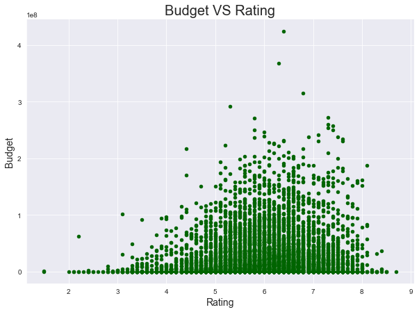

```python
# Continue to explore the data to address your additional research
#   questions. Add more headers as needed if you have more questions to
#   investigate.
df.plot(x='vote_average',y='budget_adj', kind='scatter', figsize=(10,7), color='darkgreen');
plt.ylabel('Budget', fontsize=14);
plt.xlabel('Rating', fontsize=14);
plt.title('Budget VS Rating', fontsize=20);
```

From the graph we can infer there's no apparent correlation, the distribution appears to be normal, and somewhat skewed to the left. It is an interesting fact that it seems alot of good movies didn't have a budget. Let's also check whether there's a correlation regadring the revenue and rating.

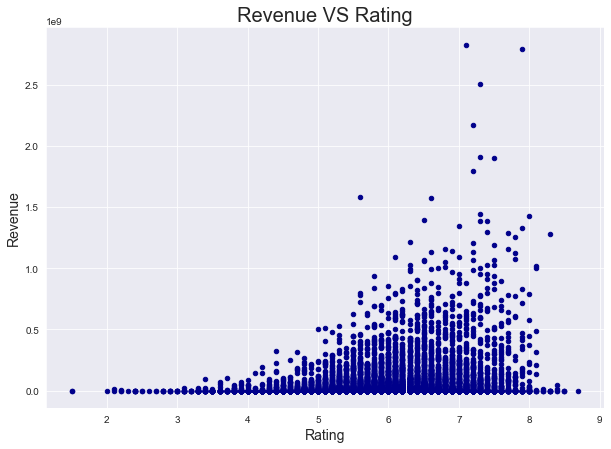

```python
df.plot(x='vote_average',y='revenue_adj', kind='scatter', figsize=(10,7), color='darkblue');
plt.ylabel('Revenue', fontsize=14);
plt.xlabel('Rating', fontsize=14);
plt.title('Revenue VS Rating', fontsize=20);
```

The revenue seems more skewed to the left than the budget, and it appears to be a small positive correlation regarding revenue vs rating

### Is there a trend regarding high rated films and production companies involved?

For this question I used a query regarding films with a vote of 8.0 or more

```python
# Continue to explore the data to address your additional research
#   questions. Add more headers as needed if you have more questions to
#   investigate.
df_high_prod = df.query('vote_average >= 8.0')
```

```python
df_high_prod.info()
```

```
<class 'pandas.core.frame.DataFrame'>
Int64Index: 60 entries, 150540 to 13963
Data columns (total 18 columns):
original_title    60 non-null object
director          60 non-null object
runtime           60 non-null int64
release_date      60 non-null object
vote_count        60 non-null int64
vote_average      60 non-null float64
release_year      60 non-null int64
budget_adj        60 non-null float64
revenue_adj       60 non-null float64
genre_1           60 non-null object
genre_2           39 non-null object
genre_3           18 non-null object
cast_1            60 non-null object
cast_2            56 non-null object
cast_3            55 non-null object
prod_comp_1       60 non-null object
prod_comp_2       36 non-null object
prod_comp_3       19 non-null object
dtypes: float64(3), int64(3), object(12)
memory usage: 8.9+ KB
```

There seems to be 60 high rated films, let see what are the main companies involved

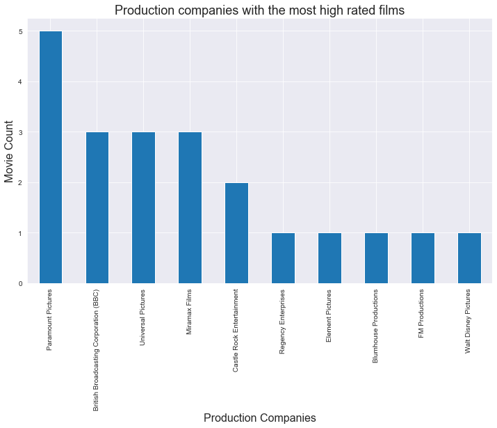

```python
df_high_prod['prod_comp_1'].value_counts().head(10).plot(kind='bar', figsize=(12,7));
plt.title('Production companies with the most high rated films', fontsize=18)
plt.xlabel('Production Companies', fontsize=16)
plt.ylabel('Movie Count', fontsize=16)
```

As suspected, the biggest production companies have the highest rating density, perhaps this is because these production companies have made a higher volume of films than the others, let's check the average of each production company

```python
df_avg_rating = df.groupby(['prod_comp_1']).mean()
```

```python
df_avg_rating.sort_values(by='vote_average', ascending=False)
```

| prod_comp_1 | runtime | vote_count | vote_average | release_year | budget_adj | revenue_adj |
| --- | --- | --- | --- | --- | --- | --- |
| SMV Enterprises | 145.00 | 23.00 | 8.700 | 2006.00 | 0.000000e+00 | 0.000000e+00 |
| Red Bull Media House | 80.00 | 60.00 | 8.500 | 2011.00 | 0.000000e+00 | 0.000000e+00 |
| Edel records GmbH | 138.00 | 14.00 | 8.500 | 1981.00 | 0.000000e+00 | 0.000000e+00 |
| Talking Heads | 88.00 | 23.00 | 8.400 | 1984.00 | 2.518850e+06 | 1.045097e+07 |
| Banger Films | 112.00 | 28.00 | 8.300 | 2009.00 | 0.000000e+00 | 0.000000e+00 |
| MSNBC Films | 95.00 | 74.00 | 8.300 | 2008.00 | 0.000000e+00 | 0.000000e+00 |
| AvÅŸar Film | 108.00 | 12.00 | 8.200 | 2005.00 | 0.000000e+00 | 0.000000e+00 |
| Apollo Associates | 80.00 | 16.00 | 8.200 | 1989.00 | 0.000000e+00 | 0.000000e+00 |
| Caméra One | 90.00 | 98.00 | 8.100 | 2013.00 | 0.000000e+00 | 0.000000e+00 |
| First Thought Films | 84.00 | 16.00 | 8.100 | 2010.00 | 0.000000e+00 | 1.339650e+06 |
| Irwin Entertainment | 60.00 | 16.00 | 8.100 | 2012.00 | 0.000000e+00 | 0.000000e+00 |
| Blue Parrot Productions | 106.00 | 1942.00 | 8.000 | 1995.00 | 8.585801e+06 | 3.340101e+07 |
| Disney | 7.00 | 507.00 | 8.000 | 2012.00 | 0.000000e+00 | 0.000000e+00 |
| NBA Entertainment | 70.00 | 11.00 | 8.000 | 2012.00 | 0.000000e+00 | 0.000000e+00 |
| Third Floor Productions | 103.00 | 54.00 | 8.000 | 1988.00 | 0.000000e+00 | 0.000000e+00 |
| First Movie Companie | 138.00 | 14.00 | 8.000 | 2015.00 | 0.000000e+00 | 0.000000e+00 |
| FM Productions | 117.00 | 33.00 | 8.000 | 1978.00 | 0.000000e+00 | 1.076189e+06 |
| Shamley Productions | 109.00 | 1180.00 | 8.000 | 1960.00 | 5.949601e+06 | 2.359350e+08 |
| LargeLab | 79.00 | 68.00 | 7.900 | 2007.00 | 0.000000e+00 | 0.000000e+00 |
| Sender Films | 99.00 | 12.00 | 7.900 | 2014.00 | 0.000000e+00 | 0.000000e+00 |
| Sky Movies | 23.00 | 79.00 | 7.900 | 2014.00 | 0.000000e+00 | 0.000000e+00 |
| Tree Tree Tree Productions | 108.00 | 23.00 | 7.900 | 2013.00 | 0.000000e+00 | 0.000000e+00 |
| Manny O Productions | 83.00 | 322.00 | 7.900 | 2013.00 | 0.000000e+00 | 0.000000e+00 |
| Grain Media | 90.00 | 55.00 | 7.900 | 2014.00 | 0.000000e+00 | 0.000000e+00 |
| Sullivan Entertainment | 199.00 | 36.00 | 7.900 | 1985.00 | 0.000000e+00 | 0.000000e+00 |
| Magidson Films | 102.00 | 83.00 | 7.900 | 2011.00 | 3.877592e+06 | 0.000000e+00 |
| Roadside Attractions | 115.50 | 133.00 | 7.850 | 2007.00 | 0.000000e+00 | 1.984574e+06 |
| Diamond Docs | 83.00 | 94.50 | 7.800 | 2010.50 | 0.000000e+00 | 1.221595e+06 |
| O2 Filmes | 90.00 | 23.00 | 7.800 | 2010.00 | 1.500000e+06 | 1.877160e+05 |
| Europa Corp. | 95.00 | 109.00 | 7.800 | 2009.00 | 0.000000e+00 | 0.000000e+00 |
| ... | ... | ... | ... | ... | ... | ... |
| The Global Asylum | 89.25 | 23.75 | 3.325 | 2011.25 | 0.000000e+00 | 0.000000e+00 |
| KK Ranch Productions | 92.00 | 12.00 | 3.300 | 2013.00 | 9.360334e+05 | 0.000000e+00 |
| Island 23 Films | 18.00 | 15.00 | 3.300 | 2015.00 | 9.199996e+00 | 0.000000e+00 |
| Enrique Cerezo Producciones Cinematográficas S.A. | 109.00 | 22.00 | 3.300 | 2012.00 | 5.318568e+06 | 7.729969e+03 |
| FatFree Films | 88.00 | 11.00 | 3.300 | 2014.00 | 0.000000e+00 | 0.000000e+00 |
| WithanO Productions | 99.00 | 21.00 | 3.300 | 2015.00 | 0.000000e+00 | 0.000000e+00 |
| Canadian Film or Video Production Tax Credit (CPTC) | 90.00 | 12.00 | 3.300 | 2013.00 | 0.000000e+00 | 0.000000e+00 |
| Cassadaga Film Production | 108.00 | 11.00 | 3.300 | 2011.00 | 0.000000e+00 | 0.000000e+00 |
| Milagro Films | 101.00 | 46.00 | 3.300 | 2002.00 | 4.849046e+07 | 2.291418e+07 |
| La.Lune Entertainment | 85.00 | 19.00 | 3.300 | 2014.00 | 5.526546e+05 | 0.000000e+00 |
| Credo Entertainment Group | 95.00 | 10.00 | 3.200 | 1997.00 | 0.000000e+00 | 0.000000e+00 |
| Safady Entertainment | 81.00 | 15.00 | 3.200 | 2015.00 | 0.000000e+00 | 0.000000e+00 |
| HJB Filmproduktion | 88.00 | 13.00 | 3.200 | 2008.00 | 4.658819e+06 | 0.000000e+00 |
| Mutressa Movies | 91.00 | 16.00 | 3.100 | 2012.00 | 4.748721e+06 | 0.000000e+00 |
| Black Sand Pictures | 94.00 | 11.00 | 3.000 | 2011.00 | 1.938796e+06 | 0.000000e+00 |
| Sci-Fi Channel | 88.00 | 12.00 | 3.000 | 2005.00 | 0.000000e+00 | 0.000000e+00 |
| Hawthorn Productions | 101.00 | 30.00 | 3.000 | 2012.00 | 2.374361e+06 | 0.000000e+00 |
| Puzzlebox Films | 75.00 | 30.00 | 2.900 | 2011.00 | 3.392893e+05 | 0.000000e+00 |
| Rootbeer Films | 101.00 | 11.00 | 2.900 | 1998.00 | 0.000000e+00 | 0.000000e+00 |
| Norcon | 95.00 | 44.00 | 2.900 | 1971.00 | 0.000000e+00 | 0.000000e+00 |
| Paris Hilton Entertainment | 91.00 | 16.00 | 2.800 | 2006.00 | 8.977854e+06 | 0.000000e+00 |
| Rapid Heart Pictures | 83.00 | 12.00 | 2.800 | 2013.00 | 0.000000e+00 | 0.000000e+00 |
| Albert Band International Productions Inc. | 84.00 | 10.00 | 2.700 | 1983.00 | 0.000000e+00 | 0.000000e+00 |
| Zentropa Productions | 91.00 | 34.00 | 2.500 | 2005.00 | 0.000000e+00 | 0.000000e+00 |
| Spy Global Media | 88.00 | 14.00 | 2.400 | 2014.00 | 1.289527e+06 | 0.000000e+00 |
| Gamma Knife Films | 90.00 | 10.00 | 2.200 | 2012.00 | 0.000000e+00 | 0.000000e+00 |
| Threshold Entertainment | 87.00 | 12.00 | 2.200 | 2012.00 | 6.173338e+07 | 7.000185e+04 |
| Rogue State | 87.00 | 17.00 | 2.100 | 2011.00 | 0.000000e+00 | 0.000000e+00 |
| Dudez Productions | 75.00 | 13.00 | 2.000 | 2012.00 | 0.000000e+00 | 0.000000e+00 |
| Norm-Iris | 74.00 | 15.00 | 1.500 | 1966.00 | 1.276423e+05 | 0.000000e+00 |

3029 rows × 6 columns

```python
df_avg_rating.loc['Paramount Pictures']['vote_average']
```

```
6.142018779342722
```

```python
df_avg_rating.loc['British Broadcasting Corporation (BBC)']['vote_average']
```

```
7.116666666666668
```

```python
df_avg_rating.loc['Universal Pictures']['vote_average']
```

```
6.071521739130432
```

```python
df_avg_rating.loc['Miramax Films']['vote_average']
```

```
6.25151515151515
```

```python
df_avg_rating.loc['Castle Rock Entertainment']['vote_average']
```

```
6.474285714285714
```

```python
df['vote_average'].mean()
```

```
5.963528448628736
```

### Is there a trend regarding cast and film rating?

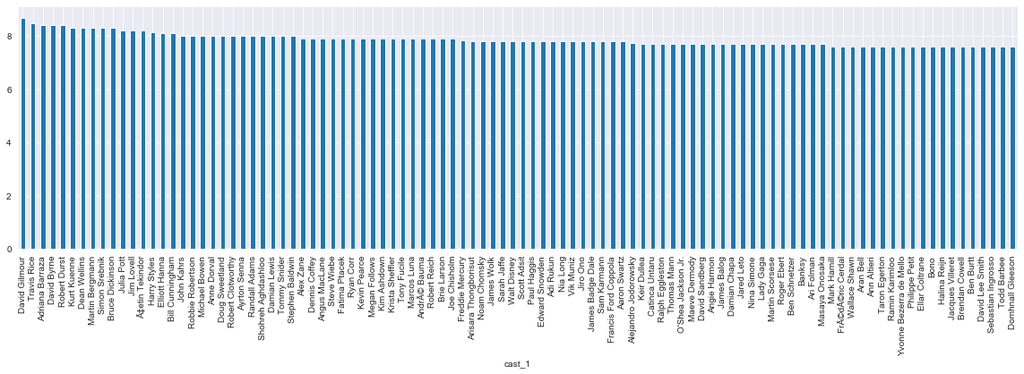

```python
# Continue to explore the data to address your additional research
#   questions. Add more headers as needed if you have more questions to
#   investigate.
df_cast = df.groupby(['cast_1'])['vote_average'].mean()
df_cast.sort_values(ascending=False).head(100).plot(kind='bar', figsize=(20,5))
```

```python
df_cast.loc['Nicolas Cage']
```

```
5.738
```

There appears to be no trend, or visible preference of ceratin actors belonging to high rated films.

### Is there a correlation between Budget and Revenue?

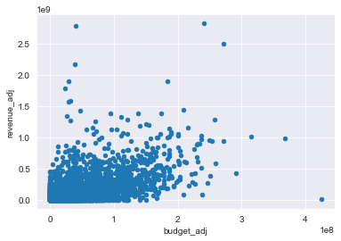

```python
# Continue to explore the data to address your additional research
#   questions. Add more headers as needed if you have more questions to
#   investigate.
df.plot(x='budget_adj', y='revenue_adj', kind='scatter')
```

### Which director produced the most succesful films, is there a trend?

```python
# Continue to explore the data to address your additional research
#   questions. Add more headers as needed if you have more questions to
#   investigate.
df.groupby(['director'])['vote_average'].mean().sort_values(ascending=False)
```

```
director
David Mallet                            8.7
Saul Swimmer                            8.5
Martin Scorsese|Michael Henry Wilson    8.5
Curt Morgan                             8.5
Jorge RamÃrez SuÃ¡rez                  8.4
                                       ...
Lawrence Kasanoff                       2.2
Justin Russell                          2.2
Brett Kelly                             2.0
Harold P. Warren                        1.5
Leigh Scott                             1.5
Name: vote_average, Length: 4505, dtype: float64
```

```python
df.loc[df['director'] == 'David Mallet']['director'].count()
```

```
1
```

David Mallet produced the highest rated films, and investigating deeper, he has directed only one film. Let's check the top five directors that have directed more movies and then review their average rating.

```python
df.groupby(['director'])['vote_average'].count().sort_values(ascending=False).head(10)
```

```
director
Woody Allen          42
Clint Eastwood       34
Steven Spielberg     29
Martin Scorsese      26
Ridley Scott         23
Steven Soderbergh    22
Ron Howard           22
Joel Schumacher      21
Brian De Palma       20
Barry Levinson       19
Name: vote_average, dtype: int64
```

```python
df.loc[df['director'] == 'Woody Allen']['vote_average'].mean()
```

```
6.485714285714285
```

```python
df.loc[df['director'] == 'Clint Eastwood']['vote_average'].mean()
```

```
6.508823529411765
```

```python
df.loc[df['director'] == 'Steven Spielberg']['vote_average'].mean()
```

```
6.824137931034483
```

```python
df.loc[df['director'] == 'Martin Scorsese']['vote_average'].mean()
```

```
6.926923076923076
```

```python
df.loc[df['director'] == 'Ridley Scott']['vote_average'].mean()
```

```
6.478260869565218
```

As suspected, the top 5 directors are Movie Industry Moguls and very experienced in what they do. We can conclude that the highest rated, experienced director is Martin Scorsese

> **Tip**: Finally, summarize your findings and the results that have been performed. Make sure that you are clear with regards to the limitations of your exploration. If you haven't done any statistical tests, do not imply any statistical conclusions. And make sure you avoid implying causation from correlation!

> **Tip**: Once you are satisfied with your work, you should save a copy of the report in HTML or PDF form via the **File** > **Download as** submenu. Before exporting your report, check over it to make sure that the flow of the report is complete. You should probably remove all of the "Tip" quotes like this one so that the presentation is as tidy as possible. Congratulations!